# ECO 530 - Exercise 1

Fall 2023 - Devan Arnold

# Q1

Consider the function:
$$y=f(x)=8\cdot x-3$$

1. Evaluate $f(x)$ at $x=3$  
   To evaluate the above expression, I will code the function as an expression and store the value of the expression in that variable $y$. Setting $x=3$ yields:

   ```r
   y <- expression(8*x-3)
   x <- 3
   eval(y)
   ```

   ```
   ## [1] 21
   ```

   Therefore, $f(x=3)=21$
2. What is the slope of the function?  
   Utilizing the above expression $y=8x-3$ we will apply the R derivative function D() to determine the slope of the function

   ```r
   y_prime <- D(y,'x')
   eval(y_prime)
   ```

   ```
   ## [1] 8
   ```

   As shown, this yields a constant value of $8$
3. How does the slope of the function at $x=3$ compare to the slope of the function at $x=6$  
   Since the slope of $y=8x-3$ is a constant value of $8$, the value of $x$ will not influence the slope of $y$. To prove this, we will run the below code:

   ```r
   x <- 3
   eval(y)
   ```

   ```
   ## [1] 21
   ```

   ```r
   eval(y_prime)
   ```

   ```
   ## [1] 8
   ```

   ```r
   x <- 6
   eval(y)
   ```

   ```
   ## [1] 45
   ```

   ```r
   eval(y_prime)
   ```

   ```
   ## [1] 8
   ```

   As we can see, $y'$ is not affected by the value of $x$, as implied by the claim of constant slope.

# Q2

Consider the function:
$$y=f(x)= 3 - x +
2\cdot x^2$$

1. Evaluate $f(x)$ at $x=3$  
   Similar to Question 1 part (a), first we will define y as an expression in terms of x

   ```r
   y <- expression(3 - x + (2*(x^2)))
   ```

   Then, we will set $x=3$ and then evaulate $y(x)$

   ```r
   x <- 3

   eval(y)
   ```

   ```
   ## [1] 18
   ```

   Resulting in $y(x=3)=18$
2. What is the slope of the function?  
   To determine the slope of the function $y(x)=f(x)$ we will use the D() function in R to set the value of the expression $y'$, which we will use the variable `y_prime` to represent:

   ```r
   y_prime <- D(y,'x')
   print(y_prime)
   ```

   ```
   ## 2 * (2 * x) - 1
   ```

   Unlike in Question 1, part (b) the slope of $y= 3 - x + 2\cdot x^2$ is NOT a constant value, and is thus dependent on the value of $x$ pursuant to the equation $y'=-1+4x$.
3. How does the slope of the function at $x=3$ compare to the slope of the function at $x=6$  
   Since $y'(x)$ is not a constant slope, the value of $y'(x=3) =/= y'(x=6)$. We can demonstrate this using the code below:

   ```r
   x <- 3
   eval(y_prime)
   ```

   ```
   ## [1] 11
   ```

   ```r
   x <- 6
   eval(y_prime)
   ```

   ```
   ## [1] 23
   ```

   As this code shows, $y'(3)=11$ and $y'(6)=23$. This is consistant with the $y'$ function derived in part (a).
4. Does this function have a maximum or a minimum? What is it?  
   To determine if the function $y$ has a minimum or maximum we will determine if there exists a root for $y'$ such that $y'(x)=0$. If this value does exist, then we will move forward to determine the nature of this point.

   ```r
   y_prime_parameters <- c(-1,4)
   y_roots <- polyroot(y_prime_parameters)
   print(y_roots)
   ```

   ```
   ## [1] 0.25+0i
   ```

   So from the above code, we can say that there does exist a root for $y'$ at $x=0.25$. Next, we need to determine if this value represents a minimum or maximum of the function. to do this, we will determine the value of $y'$ at $x$ values greater than and less than the root value of $x=0.25$.

   ```r
   x <- 0.24
   y_prime_1 <- eval(y_prime)

   x <- 0.26
   y_prime_2 <- eval(y_prime)

   if (y_prime_1 > y_prime_2){
     inflection <- "Maxima"
   } else if (y_prime_2 > y_prime_1){
     inflection <- "Minima"
   }

   results <- "The point x=0.25 represents a"
   results <- paste(results, inflection)

   print(results)
   ```

   ```
   ## [1] "The point x=0.25 represents a Minima"
   ```

   As we can see, the extrema that occurs at $x=0.25$ represents a minimum of the function $y= 3 - x + 2\cdot x^2$. We can visulize this with the following plot:

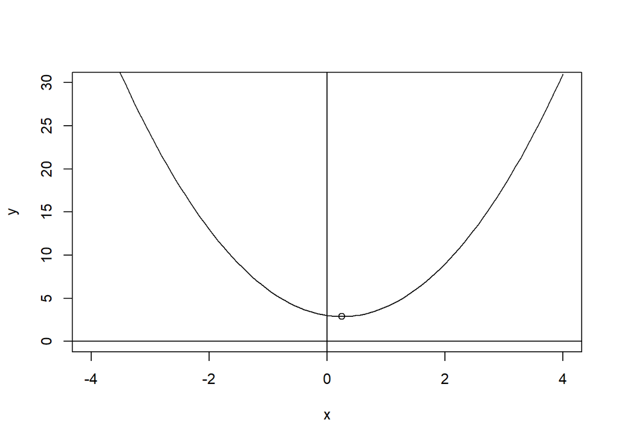

# Q3

Consider the function:
$$y=f(x,z)=100+3\cdot x^2 + 2\cdot z - 5\cdot x \cdot z$$

1. Define and derive the two elements below:
   $$\frac{\partial y}{\partial x} \quad \quad
   \quad \frac{\partial y}{\partial z}$$
   The first element is the partial derivative of $y$ with respect to $x$. We can evaluate this by treating the variable $z$ as a constant and performing derivation on $y$ with respect to $x$. This evaluates as follows:

   ```r
   y <- expression(100+3*(x^2)+2*(z)-5*(x*z))
   partial_yx <- D(y,'x')
   print(partial_yx)
   ```

   ```
   ## 3 * (2 * x) - 5 * z
   ```

   The second element is the partial derivative of $y$ with respect to $z$. As above, this represents the derivative of the $y$ function with respect to $z$ while holding the other variable, $x$, constant. This results in:

   ```r
   partial_yz <- D(y,'z')
   print(partial_yz)
   ```

   ```
   ## 2 - 5 * x
   ```

   Thus, $\frac{\partial y}{\partial x}=6x-5z$ and $\frac{\partial y}{\partial z}=2-5x$
2. Define and derive the two elements below:
   $$\frac{\partial^2 y}{\partial x^2} \quad \quad
   \quad \frac{\partial^2 y}{\partial z \partial x}$$
   The element $\frac{\partial^2 y}{\partial x^2}$ represents the second order partial derivative of $y$ with respect to $x$. We can determine this expression by taking the partial derivative of $\frac{\partial y}{\partial x}$ with respect to $x$. This evaluates as:

   ```r
   partial_yxx <- D(partial_yx,'x')
   print(partial_yxx)
   ```

   ```
   ## 3 * 2
   ```

   Thus $\frac{\partial^2 y}{\partial x^2}=6$, since we again hold $z$ values constant and treat them as such in our derivation.  
   The second element, $\frac{\partial^2 y}{\partial z \partial x}$ represents the second order partial derivative of $y$, but this time with respect to $z$ then $x$. In order to evaluate this, we can take our result from $\frac{\partial y}{\partial z}$ in part (a) and then perform partial derivation again but with respect to $x$. This evaluates as:

   ```r
   partial_yzx <- D(partial_yz,'x')
   print(partial_yzx)
   ```

   ```
   ## -5
   ```

   Thus yielding $\frac{\partial^2 y}{\partial z \partial x}=-5$ for similar reasons as above.

# Q4

Evaluate the following expressions. Show your work where necessary.

1. $\sum_{y=1}^{10} y$  
   A summation function from $y=1$ to $y=10$ of $y$. This evaluates to:

   ```r
   y <- function(lower,upper){
     output <- 0
     for(i in lower:upper){
       output <- output + i
     }
     return(output)
   }

   y(1,10)
   ```

   ```
   ## [1] 55
   ```

   Thus, $\sum_{y=1}^{10} y=55$
2. $\sum_{i=1}^{10} 5$ (or, more generally, any constant $c$)  
   A summation function from $i=1$ to $i=10$ of $5$. This evaluates to:

   ```r
   con <- function(const,lower,upper){
     output <- 0
     for(i in lower:upper){
       output <- output + const
     }
     return(output)
   }

   con(5,1,10)
   ```

   ```
   ## [1] 50
   ```

   This implies that $\sum_{i=1}^{10} 5=50$. More broadly, any constant value that has the summation operation performed over it is equal to that constant times the number of occurrences in the summation. Another way to say that is the range over which the constant is summed times the constant is the result of this operation.

   ```r
   con(10,9,10)
   ```

   ```
   ## [1] 20
   ```

   ```r
   con(3,5,10)
   ```

   ```
   ## [1] 18
   ```

   ```r
   con(2,1,2)
   ```

   ```
   ## [1] 4
   ```

3. $\frac{d f}{d x}$ where $f(x) = (12x+3)(6x^2+8x-x^3)$  
   As seen in Questions 1 & 2, derivation of functions can be performed by R, resulting in:

   ```r
   f <- expression((12*x+3)*(6*(x^2)+8*(x)-(x^3)))
   D(f,'x')
   ```

   ```
   ## 12 * (6 * (x^2) + 8 * (x) - (x^3)) + (12 * x + 3) * (6 * (2 *
   ##     x) + 8 - 3 * x^2)
   ```

   ```r
   y <- expression((12*x+3)/(6*(x^2)+8*x-(x^3)))
   y_prime <- D(y,'x')
   print(y_prime)
   ```

   ```
   ## 12/(6 * (x^2) + 8 * x - (x^3)) - (12 * x + 3) * (6 * (2 * x) +
   ##     8 - 3 * x^2)/(6 * (x^2) + 8 * x - (x^3))^2
   ```

5. $\frac{d f}{d x}$ where $f(x) = e^{-6x+2}$  
   For the equation $y=e^{f(x)}$, we employ a method similar to the product rule used in part (c). Since $e^{f(x)}$ follows the pattern $\frac{d y}{d x}=\frac{d f(x)}{d x}e^{f(x)}$ in its derivation, we can apply this form to the equation in part (e)  
   $f(x) = -6x+2$  
   $f'(x) = -6$  
   Thus, $\frac{df(x)}{dx}=-6e^{-6x+2}$  
   And once again, in R

   ```r
   y <- expression(e^((-6*x)+2))
   y_prime <- D(y,'x')
   print(y_prime)
   ```

   ```
   ## -(e^((-6 * x) + 2) * (log(e) * 6))
   ```

   Since the above log operation would be in base e (ln), the function then is just multipled by the constant 6, yielding the same result as my derivation.

# Q5

Indicate whether the following expressions are correct or incorrect. If incorrect, briefly explain why.

1. $log(x^\beta)=\beta\cdot log(x)$  
   CORRECT. This follows the power rule of logarithms
2. $log(0) = 1$  
   INCORRECT. $log(1) = 0$, but $log(0) = undefined$ as no base can be raised to a power to achieve a value of 0.
3. $log(6x) = 6\cdot log(x)$  
   INCORRECT. The product rule of logarithms states that $log(A\cdot B)=log(A)+log(B)$.
4. $log(xyz) = log(x) + log(y) + log(z)$  
   CORRECT. This follows the product rule of logarithms.
5. $log(x^2) = log(x)log(x)$  
   INCORRECT. Per the power rule of logarithms, $log(A^{B})=B\cdot log(A)$. The above represents $(log(x))^2$.
6. $\sum_{i=1}^{100} \left( X_i + Y_i + Z_i \right)= \sum_{i=1}^{100} X_i + \sum_{i=1}^{100} Y_i + \sum_{i=1}^{100} Z_i$  
   CORRECT. The summation of addition is the same as the addition of summation.
7. $\sum_{i=1}^{100} \left( X_i \cdot Y_i + Z_i \right)= \sum_{i=1}^{100} X_i \cdot \sum_{i=1}^{100} Y_i + \sum_{i=1}^{100} Z_i$  
   INCORRECT. The summation of a product is not equal to the product of summation. For example:

   ```r
   a <- 1:15
   b <- 16:30

   for(i in 1:length(a)){
     sum_product <- a[i]*b[i]
   }
   sum_product
   ```

   ```
   ## [1] 450
   ```

   ```r
   product_sum <- sum(a)*sum(b)
   product_sum
   ```

   ```
   ## [1] 41400
   ```

8. $\lim_{n \to \infty} \frac{6}{n} = 0$  
   CORRECT. Dividing a constant by a large number approaching infinity approaches 0.
9. $\lim_{n \to \infty} \frac{6n^2+n}{n^2} = 0$  
   INCORRECT. Since the numerator and denominator are both growing at the same exponential rate of $n^2$ and the numerator has an additional $n$ term, the limit as this approaches infinity would be greater than 0.
10. $\prod_{i=1}^5 y_i = y_1 \cdot y_2 \cdot y_3 \cdot y_4 \cdot y_5$  
    CORRECT. This demonstrates the correct usage of the product operation.
11. $\prod_{i=1}^5 e^{y_i} = e^{(y_1 + y_2 + y_3 + y_4 + y_5)}$  
    CORRECT. Multiplication of like bases allows you to instead add the exponents and then use the resulting sum on the base. In other words, $e^{y_1}+e^{y_2}+e^{y_3}+e^{y_4}+e^{y_5}=e^{(y_1 + y_2 + y_3 + y_4 + y_5)}$. This is the proper usage of the product function.

## For the Questions that Follow:

Assume that the $X$,$Y$, and $Z$ are independent random variables with expected values $\mu_X$, $\mu_Y$, and $\mu_Z$ and variances $\sigma^2_X$, $\sigma^2_Y$, and $\sigma^2_Z$ respectively.

# Q6

Let $W$ be a new random variable defined as:
$$W = 6X + Y - Z$$

1. What is $E[W]$?  
   Since $E[X]=\mu_x$, and by the properties of the expected value function $E[A+B]=E[A]+E[B]$ and $E[aA]=a\cdot E[A]$ we can determine that:  
   $E[W]=E[6X+Y-Z]$  
   $E[W]=E[6x]+E[Y]+E[-Z]$  
   $E[W]=6E[X]+E[Y]-E[Z]$  
   $E[W]=6\mu_x + \mu_y - \mu_z$
2. What is $\sigma^2_W$?  
   Variance has the following properties that I will utilize to evaluate $\sigma^2_w$. First, the scalar translations of random variables affect the variance by a squared factor of the scalar, such that $\sigma^2_{a\cdot A}=a^2\cdot \sigma^2_A$. Secondly, for independent random variables $A$ and $B$, the variance of their sum or difference is equal to the sum of their variances, such that $\sigma^2_{A \pm B}=\sigma^2_A + \sigma^2_B$. With these properties in mind, we can now evaluate $\sigma^2_W$.  
   $\sigma^2_W = \sigma^2_{6X+Y-Z}$  
   $\sigma^2_W = \sigma^2_{6X} + \sigma^2_Y + \sigma^2_Z$  
   $\sigma^2_W = 6^2\cdot \sigma^2_X + \sigma^2_Y + \sigma^2_Z$

# Q7

Let R be a new random variable defined as:
$$R = Y - 12$$

1. What is $E[R]$?  
   Since the expected value of a constant is a constant and a linear function, we know that $E[A+a]=E[A]+a$. Thus, the expected value of $R$ can be determined as follows:  
   $E[R]=E[Y-12]$  
   $E[R]=E[Y]+E[-12]$  
   From question 6 above, we know that $E[Y]=\mu_y$, thus  
   $E[R]= \mu_y - 12$
2. What is $\sigma^2_R$?  
   As an additional property of variance, we know that a random variable that is subjected to addition or subtraction does NOT experience changes to its variance. This is because the variation of data from the population mean is not affected by shifting the function up or down the number line by a constant - the spread of the data around the mean remains the same. Thus, $\sigma^2_{A+a}= \sigma^2_A$, allowing us to solve for $\sigma^2_R$ as follows:  
   $\sigma^2_R = \sigma^2_{Y-12}$  
   $\sigma^2_R = \sigma^2_Y$
3. Assume that $Y$ was normally distributed. Sketch the probability density functions for $Y$ and $R$.

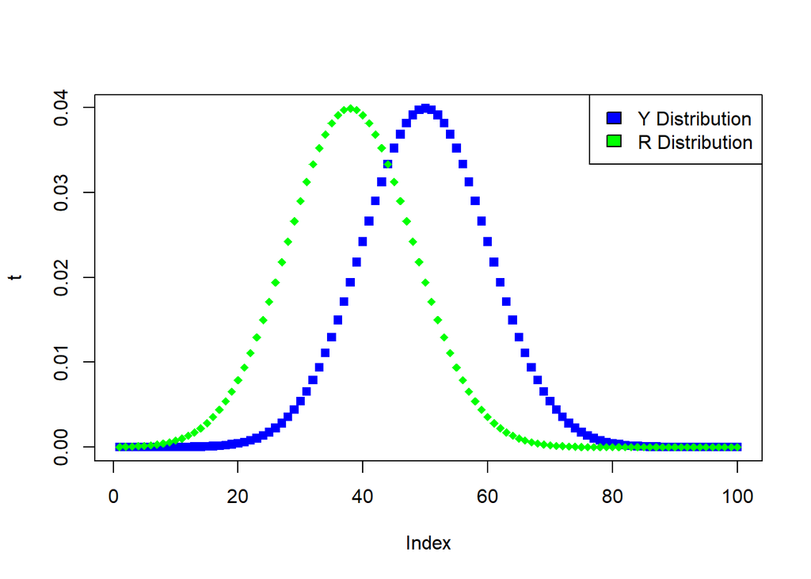

# Q8

Let Q be a new random variable defined as:
$$Q = \frac{Z - \mu_Z}{\sigma_Z}$$

1. What is $E[Q]$?  
   Since $\mu_Z$ and $\sigma_Z$ are both constant, as in they don’t vary as Z varies, they can be treated as some rational constant. Thus:  
   $E[Q]=E[\frac{Z- \mu_z}{\sigma_Z}]$  
   $E[Q]= \frac{1}{\sigma_z} E[Z-\mu_z]$  
   $E[Q]= \frac{1}{\sigma_z}(E[Z]-\mu_Z)$  
   $E[Q]=\frac{1}{\sigma_Z}(\mu_z - \mu_z)$  
   $E[Q]=\frac{1}{\sigma_Z}(0)$  
   $E[Q]=0$
2. What is $\sigma^2_Q$?  
   Using the previously derived properties of variance:  
   $\sigma^2_Q = \sigma^2_{\frac{Z - \mu_Z}{\sigma_Z}}$  
   $\sigma^2_Q = \sigma^2_{\frac{Z}{\sigma_Z} - \frac{\mu_Z}{\sigma_Z}}$  
   $\sigma^2_Q = \sigma^2_{\frac{1}{\sigma_Z}Z - \frac{\mu_Z}{\sigma_Z}}$  
   $\sigma^2_Q = \sigma^2_Z \cdot \frac{1}{\sigma_z}^2$  
   $\sigma^2_Q = 1$
3. Assume that $Y$ was normally distributed. Sketch the probability density function for $Z$ and $Q$.

[figure not shown]

# R Exercises

Write a script that allows you to answer the questions below. Submit both a text version of your answers and the (heavily commented) script that you used to generate your answers.

## R1

1. Load the tidyverse and vtable libraries.

   ```r
   #(a) Install/Load packages
   #install.packages("tidyverse")
   library(tidyverse)
   #install.packages("vtable")
   library(vtable)
   ```

   ```r
   library(ggplot2)
   # Above code only requires that the install.packages() functions be removed from
   # comment status to be run for the first time (user should delete the leading '#')
   ```

2. Set pathways to the `data'',`scripts’‘, and ``tables and figures’’ folders associated with Exercise 1.

   ```r
   #(b) Sets the file paths for data, scripts, and tables and figures
   datapath <- "F:/Users/Devan/Documents/Education/ECO530/Assignments/Assignment 1/data"
   scriptpath <- "F:/Users/Devan/Documents/Education/ECO530/Assignments/Assignment 1/scripts"
   tablesfigurespath <- "F:/Users/Devan/Documents/Education/ECO530/Assignments/Assignment 1/tables and figures"
   ```

3. Change the directory to the `data'' folder and read in the`cars.csv’’ data file.

   ```r
   #(c) Sets the working directory to the data folder
   setwd(datapath)
   # Reads the csv file name 'cars' in the datapath folder and stores the data into a
   # new data frame name cars.data
   cars.data <- read.csv("cars.csv",header=TRUE)
   ```

4. Use the summary table command () to report the contents of the data.

   ```r
   #(d) Creates a summary table of the cars.data data frame
   st(cars.data)
   ```

   Summary Statistics

   | Variable | N | Mean | Std. Dev. | Min | Pctl. 25 | Pctl. 75 | Max |
   | --- | --- | --- | --- | --- | --- | --- | --- |
   | price | 74 | 6165 | 2949 | 3291 | 4220 | 6332 | 15906 |
   | mpg | 74 | 21 | 5.8 | 12 | 18 | 25 | 41 |
   | rep78 | 69 | 3.4 | 0.99 | 1 | 3 | 4 | 5 |
   | headroom | 74 | 3 | 0.85 | 1.5 | 2.5 | 3.5 | 5 |
   | trunk | 74 | 14 | 4.3 | 5 | 10 | 17 | 23 |
   | weight | 74 | 3019 | 777 | 1760 | 2250 | 3600 | 4840 |
   | length | 74 | 188 | 22 | 142 | 170 | 204 | 233 |
   | turn | 74 | 40 | 4.4 | 31 | 36 | 43 | 51 |
   | displacement | 74 | 197 | 92 | 79 | 119 | 245 | 425 |
   | gear_ratio | 74 | 3 | 0.46 | 2.2 | 2.7 | 3.4 | 3.9 |
   | foreign | 74 |  |  |  |  |  |  |
   | … Domestic | 52 | 70% |  |  |  |  |  |
   | … Foreign | 22 | 30% |  |  |  |  |  |

## R2

Starting with the ``cars’’ data frame:

1. Use `group_by()` and summarize() to create a data frame called ``summary’’ containing the average price, mpg, and weight of Foreign/Domestic cars in the data.

   ```r
   #(a) Creates a summary of the average mpg, weight, and price of cars grouped by
   # their foreign or domestic status. Stores the data in the summary.data data frame
   summary.data <- cars.data %>%
     group_by(foreign) %>%
     summarize("Avg. MPG" = round(mean(mpg),digits=1),
               "Avg. Weight" = round(mean(weight),digits=0),
               "Avg. Price" = round(mean(price),digits=2))
   summary.data
   ```

   ```
   ## # A tibble: 2 × 4
   ##   foreign  `Avg. MPG` `Avg. Weight` `Avg. Price`
   ##   <chr>         <dbl>         <dbl>        <dbl>
   ## 1 Domestic       19.8          3317        6072.
   ## 2 Foreign        24.8          2316        6385.
   ```

2. Use `kable()` to make a nicely formatted version of your ``summary()’’ data frame.

   ```r
   #(b) Creates a formatted table from the summary.data data frame
   kable(summary.data)
   ```

   | foreign | Avg. MPG | Avg. Weight | Avg. Price |
   | --- | --- | --- | --- |
   | Domestic | 19.8 | 3317 | 6072.42 |
   | Foreign | 24.8 | 2316 | 6384.68 |

3. Make a new data frame containing only Domestic Cars called “domestic.cars”

   ```r
   #(c) Creates a new data frame named domestic.cars with only information from cars.data
   # on domestically manufactured cars.
   domestic.cars <- cars.data[cars.data$foreign=="Domestic",]
   domestic.cars
   ```

   ```
   ##                 make price mpg rep78 headroom trunk weight length turn
   ## 1        AMC Concord  4099  22     3      2.5    11   2930    186   40
   ## 2          AMC Pacer  4749  17     3      3.0    11   3350    173   40
   ## 3         AMC Spirit  3799  22    NA      3.0    12   2640    168   35
   ## 4      Buick Century  4816  20     3      4.5    16   3250    196   40
   ## 5      Buick Electra  7827  15     4      4.0    20   4080    222   43
   ## 6      Buick LeSabre  5788  18     3      4.0    21   3670    218   43
   ## 7         Buick Opel  4453  26    NA      3.0    10   2230    170   34
   ## 8        Buick Regal  5189  20     3      2.0    16   3280    200   42
   ## 9      Buick Riviera 10372  16     3      3.5    17   3880    207   43
   ## 10     Buick Skylark  4082  19     3      3.5    13   3400    200   42
   ## 11      Cad. Deville 11385  14     3      4.0    20   4330    221   44
   ## 12     Cad. Eldorado 14500  14     2      3.5    16   3900    204   43
   ## 13      Cad. Seville 15906  21     3      3.0    13   4290    204   45
   ## 14    Chev. Chevette  3299  29     3      2.5     9   2110    163   34
   ```

   [output cut: 91 more lines]

4. Add a variable (using the mutate() function) to the domestic.cars data frame that is equal to `price'' divided by`mpg’’.

   ```r
   #(d) Adds a column to the domestic.cars data frame that contains the value of
   # that car's price divided by its mpg rating. Rounds to 1 digit after the decimal.
   domestic.cars<-  domestic.cars %>% mutate(pricepermpg = round(price/mpg,digits=1))
   domestic.cars
   ```

   ```
   ##                 make price mpg rep78 headroom trunk weight length turn
   ## 1        AMC Concord  4099  22     3      2.5    11   2930    186   40
   ## 2          AMC Pacer  4749  17     3      3.0    11   3350    173   40
   ## 3         AMC Spirit  3799  22    NA      3.0    12   2640    168   35
   ## 4      Buick Century  4816  20     3      4.5    16   3250    196   40
   ## 5      Buick Electra  7827  15     4      4.0    20   4080    222   43
   ## 6      Buick LeSabre  5788  18     3      4.0    21   3670    218   43
   ## 7         Buick Opel  4453  26    NA      3.0    10   2230    170   34
   ## 8        Buick Regal  5189  20     3      2.0    16   3280    200   42
   ## 9      Buick Riviera 10372  16     3      3.5    17   3880    207   43
   ## 10     Buick Skylark  4082  19     3      3.5    13   3400    200   42
   ## 11      Cad. Deville 11385  14     3      4.0    20   4330    221   44
   ## 12     Cad. Eldorado 14500  14     2      3.5    16   3900    204   43
   ## 13      Cad. Seville 15906  21     3      3.0    13   4290    204   45
   ## 14    Chev. Chevette  3299  29     3      2.5     9   2110    163   34
   ```

   [output cut: 91 more lines]

## R3

Generate vectors containing 250 draws from each of the following normal distributions:

- $var1 \sim N(3,1)$
- $var2 \sim N(-1,2)$
- $var3 \sim N(2,3)$

Place all three variables in a data frame together called ``random.draws’’. Include in your data frame a variable called “id” that indicates an observations row number.

````
```r
# Creates var1, var2, and var3. Performs 250 draws from a normal distribution
# based on the mean and standard deviation provided
var1 <- rnorm(250,mean=3,sd=sqrt(1))
var2 <- rnorm(250,mean=-1,sd=sqrt(2))
var3 <- rnorm(250,mean=2,sd=sqrt(3))

# Creates the id variable for later use
id <- 1:250

# Creates the 'random.draws' data frame by combining the vectors var1, var2, and var3
random.draws <- data.frame(id,var1,var2,var3)
random.draws
```

````

[output cut: 253 more lines]

# R4

Generate a scatter plot of `var1`. Make sure that your scatter plot has a title and informative labels on the axes.

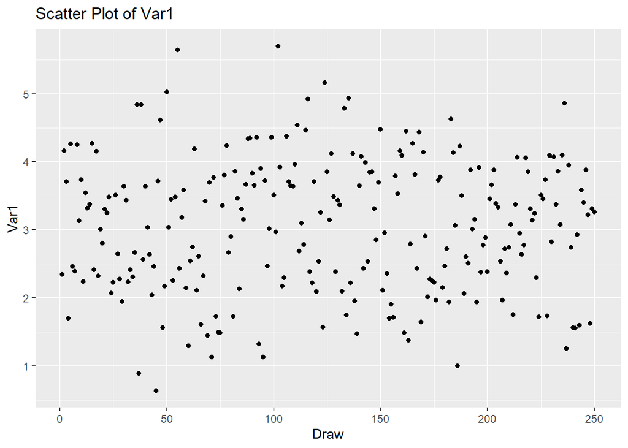

# R5

Generate a density plot of `var2`. Choose a fill color different than ggplot()’s default.

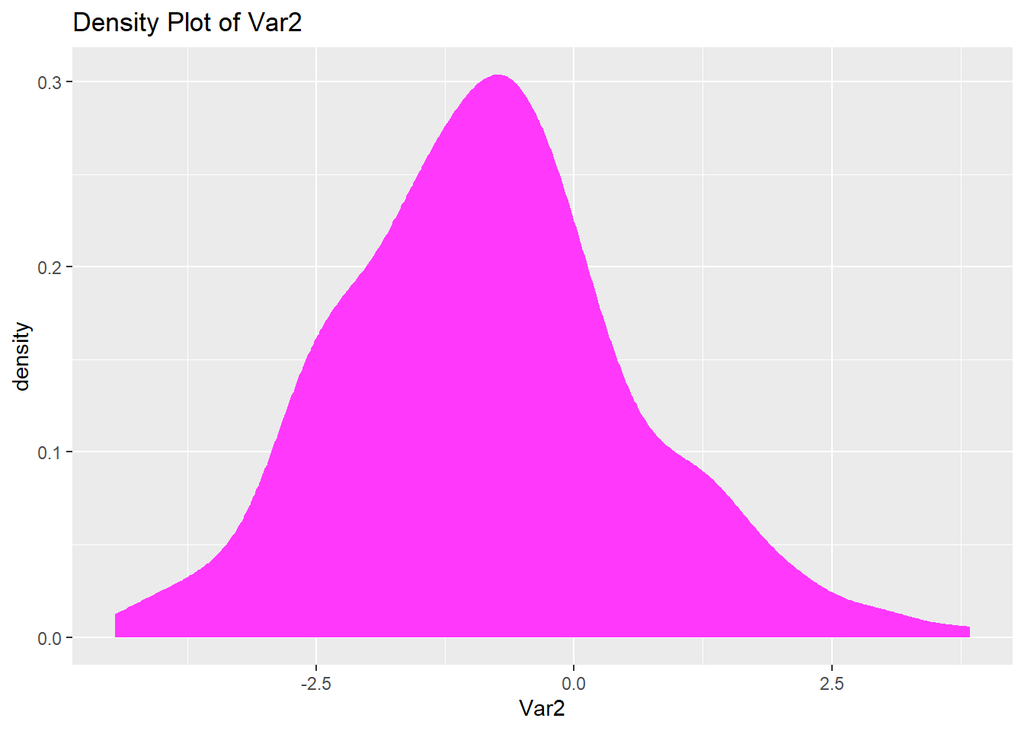

# R6

Create a new variable in your data frame called `var4` that is equal to the sum of the other three.

````
```r
# Creates var4 as a summation of vars 1, 2, & 3 and assigns it to the random.draws data frame
random.draws <- random.draws %>% mutate(var4 = var1 + var2 + var3)
```
````

a. Where do you expect it’s density to be centered when you plot it?  
Since var4 is a combination of vars 1-3, I suspect that the expected value of var4 should be equal to 4. This is because $E[var1]=\mu_{var1}$, and since $var4 = var1 + var2 + var3$ ->  
$E[var4] = E[var1 + var2 + var3]$  
$E[var4] = E[var1] + E[var2] + E[var3]$  
$E[var4]= \mu_{var1} + \mu_{var2} + \mu_{var3}$  
$E[var4] = 3 + (-1) + 2$  
$E[var4] = 4$  
b. Create a density plot of your new variable, placing a dashed, vertical line at it’s expected value.

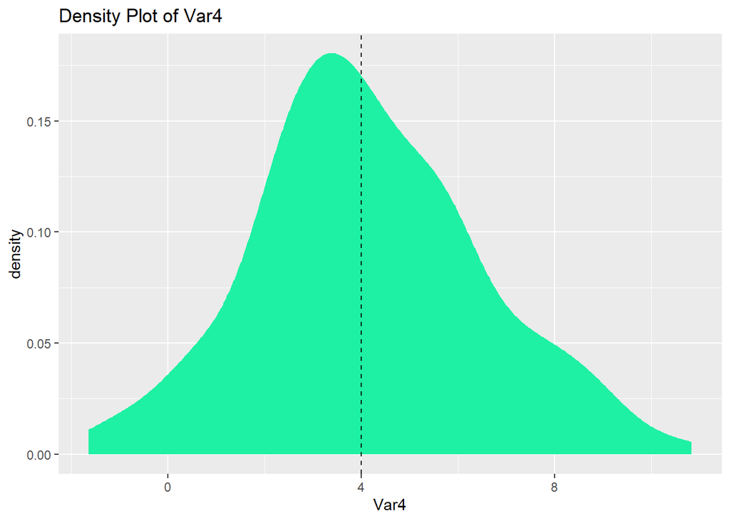

# R7

Create a new variable in your data frame called `var5` by subtracting one from each element in `var3` and dividing each element by 2.  
a. Where do you expect the new variable’s density to be centered?  
I expect that the new density plot will be centered around x=0.5. This represents the expected value of var5, which is $E[var5]=E[(var3 - 1)/2]$  
$E[var5]= \frac{1}{2} E[var3 - 1]$  
$E[var5]= \frac{1}{2}(E[var3] - 1)$  
$E[var5]= \frac{1}{2}(2-1)$  
$E[var5]= \frac{1}{2}(1) = 0.5$  
b. How else do you expect it to change?  
Since the coefficient of $\frac{1}{2}$ is part of the var5 transformation, I expect to see tighter grouping of values around the mean. In other words, $\sigma^2_{var5} < \sigma^2_{var3}$. This is drawn from the variance properties utilized earlier in the excerise.  
c. Create a density plot of your new variable placing a dashed, vertical line at it’s expected value.

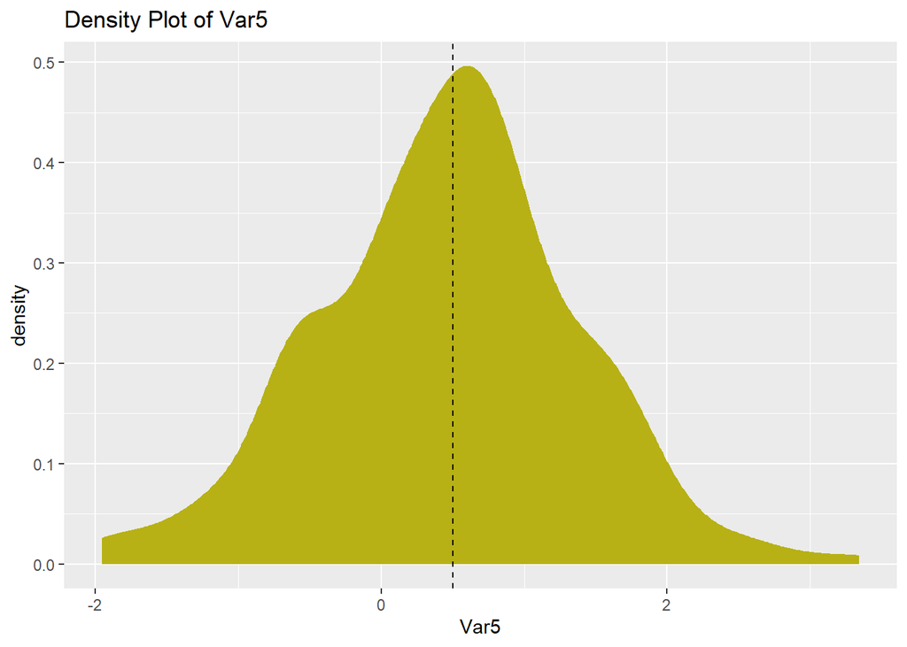